# Baseline Methods for Rating Prediction

STAT3009 · Recommender Systems

Ben Dai

CUHK · Department of Statistics and Data Science

## The Netflix rating-prediction pipeline

TRAIN.CSV: OBSERVED TRIPLE**(1960, 670, 4)**

User 1960 gave movie 670 four stars. The model may learn from this row.

TEST.CSV: PREDICTION PAIR**(1574, 2956, ?)**

The model sees the user and movie. The rating stays hidden until evaluation.

01**Inspect**

`train` has 51,161 observed triples with user, movie and rating.

*then*

02**Standardize IDs**

Fit shared ID maps. Create `X_train`, `y_train` and `X_test`.

*then*

03**Fit a predictor**

Learn an abstract scoring rule `f_theta` from the training arrays.

*then*

04**Predict and evaluate**

Compute `y_pred`. Reveal `y_test` only when calculating RMSE.

*then*

05**Rank**

For user 1960, movies 2098, 898 and 2195 are ordered by `y_pred`.

**Row alignment stays fixed:** `X_test[j]` receives `y_pred[j]`, which is later compared with `y_test[j]`.

## Netflix data preparation and prediction

TRAIN LANE: RAW DATA **train.csv**

| u | i | r |
| --- | --- | --- |
| 1960 | 670 | 4 |
| 1346 | 152 | 4 |

collect IDs

TEST LANE: HIDDEN TARGET **test.csv**

| u | i | r |
| --- | --- | --- |
| 1574 | 2956 | ? |
| 1670 | 791 | ? |

collect IDs

1: DATA STANDARDIZATION **One shared ID map** `fit on concat(train, test)`

`1960`**u_k**

`670`**i_l**

Raw IDs are labels. Encoded indices are contiguous and start at zero.

*The same raw ID must receive the same index in both splits.*

transform

2: TRAINING ARRAYS **Inputs and targets** `X_train[j] = [u_idx, i_idx]` `y_train[j] = rating`

Each row remains aligned.

learn

transform

2: PREDICTION INPUT **Test pairs** `X_test[j] = [u_idx, i_idx]` *y_test stays hidden*

Keep the original test-row order.

score

3: ABSTRACT PREDICTOR **Learn a scoring rule**

`f_theta = learn(X_train, y_train)``y_pred[j] = f_theta(X_test[j])`**one score per test pair**

We will define how `f_theta` works later.

compare

sort

EVALUATE **Reveal y_test** `RMSE(y_test, y_pred)`

One score over 51,161 test rows.

RANK **User 1960**

1. `2098`**3.81**
2. `898`**3.73**
3. `2195`**3.28**

The same ID maps transform both splits. The model learns from training ratings, then returns one prediction for every test pair.

## A baseline must score every test pair

TRAINING RATINGS**Ω<sup>tr</sup>**

Information the model may use.

*fit*

PREDICTION RULE**f(u, i)**

A complete rule, including fallbacks.

*predict*

TEST PAIRS**(u, i)**

Pairs excluded from model fitting.

*score*

TEST RMSE**lower is better**

One comparable number for every method.

**Simple**We can explain every prediction.

**Complete**New users and movies still receive a score.

**Reproducible**The same training data gives the same benchmark.

## Data preprocessing: categorical IDs

**User and item IDs are labels.** The model needs stable array indices, but the spelling or numerical size of an ID carries no preference information.

USER LABELS `["U_A", "U_Z", "U_A"]` *fit user vocabulary* USER INDICES `[0, 1, 0]`

MOVIE LABELS `["M_B", "M_A", "M_C"]` *fit movie vocabulary* MOVIE INDICES `[1, 0, 2]`

RAW LABEL**`“U_Z”`**

An identifier. Its characters carry no distance or order.

ARRAY INDEX**`1`**

A valid zero-based position in a NumPy array.

**Use two encoders:** users and movies have separate vocabularies, even when both happen to be integers.

## sklearn.preprocessing.LabelEncoder

PACKAGE**sklearn**

*.*

MODULE**preprocessing**

*.*

CLASS**LabelEncoder**

`from sklearn.preprocessing import LabelEncoder`

```python
enc = LabelEncoder()
labels = ["U_A", "U_Z", "U_A"]

enc.fit(labels)
enc.classes_                       # ["U_A", "U_Z"]

enc.transform(["U_Z", "U_A"])    # [1, 0]
enc.inverse_transform([0, 1])      # ["U_A", "U_Z"]
```

01**`LabelEncoder()`***Creates an encoder with no learned vocabulary.*

02**`fit(labels)`***Finds the unique labels and stores them in `classes_`.*

03**`transform(labels)`***Applies the stored mapping to known labels.*

04**`inverse_transform(indices)`***Converts integer indices back to the original labels.*

`fit` changes the encoder’s state. `transform` reuses that state and cannot invent an index for an unseen label.

## Train-only ID vocabulary

TRAIN TRIPLES **Observed ratings**

| user | movie | rating |
| --- | --- | --- |
| U_A | M_A | 4 |
| U_C | M_B | 5 |
| U_A | M_B | 3 |

fit

FIT ON TRAIN ONLY **User vocabulary** `U_A: 0 U_C: 1` **Movie vocabulary** `M_A: 0 M_B: 1`

transform test

TEST PAIRS **Pairs to score**

| user | movie |
| --- | --- |
| U_B **unseen** | M_A |
| U_C | M_C **unseen** |

TRANSFORM CANNOT CONTINUE `U_B is absent from the user vocabulary` `M_C is absent from the movie vocabulary`

The course split contains test-only IDs. A train-only encoder cannot assign every scheduled test pair an index.

## Shared train–test ID vocabulary

ID COLUMNS ONLY

**train users**`U_A, U_C, U_A`

**test users**`U_B, U_C`

**train movies**`M_A, M_B, M_B`

**test movies**`M_A, M_C`

concatenate IDs

FIT ONCE **Shared user map** `U_A: 0 U_B: 1 U_C: 2` **Shared movie map** `M_A: 0 M_B: 1 M_C: 2`

transform separately

KEEP THE SPLITS

**encoded train**`[0,0] [2,1] [0,1]`

**encoded test**`[1,0] [2,2]`

WHAT ENTERS THE ENCODER? **`user_id` and `movie_id`** WHAT STAYS OUT? **`test.rating`**

Concatenation defines a common vocabulary. It does not merge the ratings or move test rows into the training set.

## LabelEncoder implementation

```python
from sklearn.preprocessing import LabelEncoder

all_users = pd.concat([train["user_id"], test["user_id"]])
all_items = pd.concat([train["movie_id"], test["movie_id"]])

user_enc = LabelEncoder().fit(all_users)
item_enc = LabelEncoder().fit(all_items)

train["u"] = user_enc.transform(train["user_id"])
test["u"]  = user_enc.transform(test["user_id"])
train["i"] = item_enc.transform(train["movie_id"])
test["i"]  = item_enc.transform(test["movie_id"])

n_users = len(user_enc.classes_)
n_items = len(item_enc.classes_)
```

01**Collect ID columns***No ratings enter `all_users` or `all_items`.*

02**Fit once***Each encoder stores one shared vocabulary.*

03**Transform separately***Train and test remain different datasets.*

`fit` defines the mapping. `transform` applies the same mapping wherever that entity appears.

## Data preprocessing: NumPy arrays

TRAIN DATAFRAME**u, i, rating**

51,161 observed triples

split columns

MODEL INPUT**X_train**`(51161, 2)`*columns [u, i]*

TRAINING TARGET**y_train**`(51161,)`*observed ratings*

NUMPY METHOD**fit on train****predict X_test**

MODEL INPUT**X_test**`(51161, 2)`*columns [u, i]*

MODEL OUTPUT**y_pred**`(51161,)`*one score per row*

```
X_train = train[["u", "i"]].to_numpy(dtype=np.int64)
y_train = train["rating"].to_numpy(dtype=float)

X_test = test[["u", "i"]].to_numpy(dtype=np.int64)
y_test = test["rating"].to_numpy(dtype=float)  # evaluation only
```

IMPLEMENTATION RULE **Pandas prepares the tables.** **NumPy fits every baseline and produces `y_pred`.**

During prediction, the method receives `X_test`. We reveal `y_test` only when calculating RMSE.

## Netflix data and evaluation

01

Understand the observations, the missing pairs, and the information available at prediction time.

## The Netflix Prize made rating prediction measurable

PRIZE**US$1 million**

for reaching the competition target

TARGET**10% improvement**

over the Cinematch benchmark

TASK**Predict hidden ratings**

for specified customer–movie pairs

The competition reduced recommendation to a precise offline problem: estimate a customer’s missing movie rating.

Source: [Netflix Prize](https://www.netflixprize.com/) and the [Netflix dataset README](https://www.kaggle.com/datasets/netflix-inc/netflix-prize-data).

## The full data and the course subset

|  | Netflix Prize | STAT3009 subset |
| --- | --- | --- |
| Training ratings | 100,480,507 | 51,161 |
| Users | 480,189 | 2,000 |
| Movies | 17,770 | 3,568 |
| Rating scale | 1–5 stars | 1–5 stars |
| Test labels | Hidden | Visible for teaching |

PYTHON · COURSE FILES

```
both = pd.concat([train, test])

len(train)
both[["user_id", "movie_id"]].nunique()
train["rating"].agg(["min", "max"])
```

**51,161** rows  
**2,000** users · **3,568** movies  
ratings from **1** to **5**

**How to read the comparison**Python gives the subset counts. The original counts come from the competition README.

Sources: [Netflix dataset README](https://www.kaggle.com/datasets/netflix-inc/netflix-prize-data) and [STAT3009 course data](https://github.com/statmlben/CUHK-STAT3009/tree/main/dataset/netflix).

## Competition split and course split

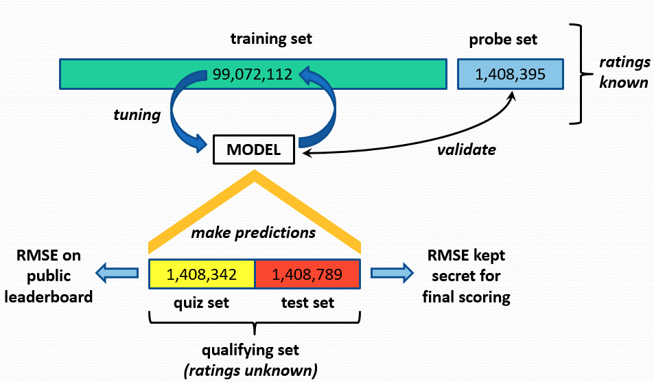

Source: [Pantelis Monogioudis, Netflix Prize lecture notes](https://pantelis.github.io/cs301/docs/common/lectures/recommenders/netflix/).

FIT**Training · 99,072,112***Released ratings used to estimate the model.*

VALIDATE**Probe · 1,408,395***Known ratings held out for local model checks.*

PUBLIC FEEDBACK**Quiz · 1,408,342***Hidden ratings produced the leaderboard score.*

FINAL DECISION**Test · 1,408,789***Hidden ratings determined the final ranking.*

`100,480,507 = 99,072,112 + 1,408,395`The released rating total includes the fitting and probe portions.

**Course version**`train.csv` fits the model. We hide the `test.csv` rating column while predicting, then reveal it to calculate RMSE.

## The course tables

```python
import numpy as np
import pandas as pd

base = (
    "https://raw.githubusercontent.com/"
    "statmlben/CUHK-STAT3009/main/"
    "dataset/netflix/"
)

fields = ["movie_id", "user_id", "rating"]
train = pd.read_csv(base + "train.csv", usecols=fields)
test = pd.read_csv(base + "test.csv", usecols=fields)
```

train.head()

|  | movie_id | user_id | rating |
| --- | --- | --- | --- |
| 0 | 670 | 1960 | 4 |
| 1 | 152 | 1346 | 4 |
| 2 | 1741 | 785 | 4 |
| 3 | 3032 | 686 | 5 |
| 4 | 536 | 1894 | 4 |

**(1960, 670, 4)** means customer 1960 gave movie 670 four stars.

IDs identify categories. Their numerical distance carries no meaning.

## Rating distribution in the training set

1 star

**2,347***4.6%*

2 stars

**5,051***9.9%*

3 stars

**14,400***28.1%*

4 stars

**17,202***33.6%*

5 stars

**12,161***23.8%*

PYTHON

```
train["rating"].value_counts(
    normalize=True
).sort_index()

train["rating"].agg(["mean", "std"])
```

TRAINING MEAN**3.621**

TRAINING SD**1.088**

3–5 STAR RATINGS**85.5%**

The target is not centered at three stars. A credible first prediction should reflect this.

## The observed matrix is 0.717% full

POSSIBLE USER–MOVIE PAIRS**2,000 × 3,568***7,136,000 cells*

OBSERVED TRAINING RATINGS**51,161***one rating per observed pair*

PYTHON

```
both = pd.concat([train, test])
n_user = both["user_id"].nunique()
n_movie = both["movie_id"].nunique()

density = len(train) / (n_user * n_movie)
100 * density
```

**0.7169%**

**0.717%** observed **99.283%** unobserved

A blank cell means “no observed rating.” It does not mean that the customer assigned zero stars.

## Interaction counts vary sharply

RATINGS PER USER IN TRAIN

| Median | 13 |
| --- | --- |
| 90th percentile | 65 |
| Maximum | 535 |

RATINGS PER MOVIE IN TRAIN

| Median | 3 |
| --- | --- |
| 90th percentile | 41 |
| Maximum | 411 |

PYTHON · GROUP SIZE, THEN SUMMARIZE

```
user_n = train.groupby("user_id").size()
movie_n = train.groupby("movie_id").size()
user_n.quantile([.5, .9]), user_n.max()
movie_n.quantile([.5, .9]), movie_n.max()
```

The group means summarize different amounts of evidence: some users and movies have many more ratings than others.

## Train and test contain different pairs

TRAIN**51,161 pairs**

Used to estimate every mean and model parameter.

**0**overlapping user–movie pairs

TEST**51,161 pairs**

Ratings enter the RMSE calculation only.

USERS**74 unseen in train***1,843 users occur in both files*

MOVIES**584 unseen in train***2,415 movies occur in both files*

PYTHON

```
keys = ["user_id", "movie_id"]
n_overlap = train.merge(test, on=keys).shape[0]
new_users = len(set(test.user_id) - set(train.user_id))
new_movies = len(set(test.movie_id) - set(train.movie_id))
```

**0** overlapping pairs · **74** new users · **584** new movies

## Four types of test pair

| Test pair | User / movie seen? | Rows | Share |
| --- | --- | --- | --- |
| Warm pair | Yes / Yes | 50,159 | 98.04% |
| New movie | Yes / No | 850 | 1.66% |
| New user | No / Yes | 149 | 0.29% |
| New user and movie | No / No | 3 | 0.01% |

PYTHON

```
seen_u = test.user_id.isin(train.user_id)
seen_i = test.movie_id.isin(train.movie_id)

pd.crosstab(seen_u, seen_i)
```

**A held-out pair can still contain familiar IDs.**Fallbacks cover the 1,002 rows with a new user or movie.

## Leakage-free evaluation

TRAIN RATINGS**Fit summaries**

global mean, user effects, movie effects

*use fitted values*

TEST IDs**Generate predictions**

one score for every test row

*after prediction*

TEST RATINGS**Calculate RMSE**

compare truth with predictions

DATA LEAKAGE **Computing a user or movie mean from `pd.concat([train, test])` lets test ratings influence the prediction.**

Use both files only to describe the dataset universe, never to fit a predictive quantity.

## RMSE as the common scoreboard

$$\operatorname{RMSE}
=
\sqrt{\frac{1}{n_{\mathrm{test}}}
\sum_{j=1}^{n_{\mathrm{test}}}(y_j-\hat y_j)^2}$$

**Interpretation**Typical prediction error, expressed on the 1–5 rating scale, with larger misses penalized more heavily.

```python
def rmse(y_true, y_pred):
    error = np.asarray(y_true) - np.asarray(y_pred)
    return np.sqrt(np.mean(error ** 2))

# test ratings enter only here
score = rmse(y_test, y_pred)
```

EVERY METHOD RETURNS**51,161 predictions**

in the same row order as `test`

## From training triples to a prediction vector

TRAIN · THREE-COLUMN LIST OF (u, i, r)

| u | i | r |
| --- | --- | --- |
| 1960 | 670 | 4 |
| 1346 | 152 | 4 |
| 785 | 1741 | 4 |
| 686 | 3032 | 5 |

Learn which systematic patterns explain *r*.

summarize

PREDICTION RULE **r̂<sub>ui</sub> = rule(u, i)**

Use quantities calculated only from `train`.

global leveluser patternmovie pattern

apply row by row

TEST PAIRS AND ALIGNED OUTPUT

**test[[“user_id”, “movie_id”]]**

1. 15742956
2. 1670791
3. 8371547
4. 19431846

**y_pred**

1. 3.84
2. 3.35
3. 3.43
4. 3.44

Row *j* in the vector predicts row *j* in `test`.

`len(y_pred) == len(test)`

The model never reads `test[“rating”]`. We use that column only after the vector is complete.

## Mean baselines

02

Use progressively more specific averages while retaining a prediction for every test row.

## Global mean baseline

ONE NUMBER FROM TRAIN
$$\mu=\frac{1}{|\Omega^{\mathrm{tr}}|}\sum_{(u,i)\in\Omega^{\mathrm{tr}}}r_{ui}
\qquad
\hat r_{ui}=\mu$$

TRAINING MEAN**3.621**

TEST RMSE**1.085**

UNSEEN IDS**Always defined**

The rating distribution gives us a stronger constant prediction than an arbitrary midpoint such as three stars.

## Global mean from the training triples

TRAIN · 51,161 TRIPLES

| u | i | r |
| --- | --- | --- |
| 1960 | 670 | 4 |
| 1346 | 152 | 4 |
| 785 | 1741 | 4 |
| 686 | 3032 | 5 |
| 1894 | 536 | 4 |
| ⋮ | ⋮ | ⋮ |

The global mean uses the `r` column. It does not group by `u` or `i`.

aggregate r

SUM OF ALL RATINGS**185,262**`y_train.sum()`

NUMBER OF RATINGS**51,161**`y_train.size`

GLOBAL MEAN

**185,262****51,161**

*=***3.621156…**

CALCULATE`global_mean = y_train.mean()`

FILL THE TEST VECTOR`y_pred_global = np.full(X_test.shape[0], global_mean)`

## Systematic variation across users and movies

USER RATING LEVELS

**User 589***74 ratings***2.01**

**User 1190***74 ratings***4.99**

MOVIE RATING LEVELS

**Movie 2341***64 ratings***2.75**

**Movie 205***81 ratings***4.49**

One global number leaves predictable structure in the prediction errors: some users rate low, and some movies receive stronger ratings.

## User mean baseline

ONE NUMBER PER OBSERVED USER
$$\bar r_u=\frac{1}{|\mathcal I_u^{\mathrm{tr}}|}
\sum_{i\in\mathcal I_u^{\mathrm{tr}}}r_{ui}$$

KNOWN USER**r̂<sub>ui</sub> = r̄<sub>u</sub>***same prediction for every movie*

NEW USER**r̂<sub>ui</sub> = μ***fall back to the global mean*

TEST RMSE**1.017**

CHANGE FROM GLOBAL**−0.069**

## User means from training triples

SELECTED TRAIN TRIPLES · USERS INTERLEAVED

| u | i | r |
| --- | --- | --- |
| 1960 | 670 | 4 |
| 589 | 3181 | 1 |
| 1346 | 152 | 4 |
| 1960 | 2597 | 4 |
| 589 | 422 | 2 |
| 1346 | 2102 | 5 |

Rows with the same `u` belong to one group. The movie IDs may differ.

group by u

ONE AVERAGE PER USER GROUP

| User | Σr / n<sub>u</sub> | User mean |
| --- | --- | --- |
| 1960 | 1,324 / 347 | 3.816 |
| 589 | 149 / 74 | 2.014 |
| 1346 | 398 / 107 | 3.720 |

**Same calculation, separate groups**Each observed user receives one value. User 1960 gets `1324 / 347 = 3.815562`.

STORE ONE VALUE PER USER

```
user_mean[1960] = 3.816
user_mean[589]  = 2.014
user_mean[1346] = 3.720
```

## User mean in NumPy

```python
user_mean = np.full(n_users, global_mean)

for u in np.unique(X_train[:, 0]):
    user_mean[u] = np.mean(y_train[X_train[:, 0] == u])

y_pred_user = user_mean[X_test[:, 0]]
```

EXAMPLE · USER u = 1

**User column**`[0, 1, 0, 2, 1]`

**Boolean mask**`[F, T, F, F, T]`

**Selected ratings**`[1, 2]`

**user_mean[1]**`1.5`

**Build the lookup vector from train**`X_train[:, 0] == u` selects the ratings from user `u`.

**Predict by array indexing**Each encoded test user retrieves one value from `user_mean`.

## Item mean baseline

ONE NUMBER PER OBSERVED MOVIE
$$\bar r_i=\frac{1}{|\mathcal U_i^{\mathrm{tr}}|}
\sum_{u\in\mathcal U_i^{\mathrm{tr}}}r_{ui}$$

KNOWN MOVIE**r̂<sub>ui</sub> = r̄<sub>i</sub>***same prediction for every user*

NEW MOVIE**r̂<sub>ui</sub> = μ***fall back to the global mean*

TEST RMSE**1.052**

CHANGE FROM GLOBAL**−0.034**

## Item mean uses the same pattern

SELECTED TRAIN TRIPLES · MOVIES INTERLEAVED

| u | i | r |
| --- | --- | --- |
| 1960 | 670 | 4 |
| 1346 | 152 | 4 |
| 785 | 1741 | 4 |
| 1882 | 670 | 4 |
| 657 | 152 | 2 |
| 961 | 1741 | 4 |

Rows with the same `i` belong to one group. The user IDs may differ.

group by i

ONE AVERAGE PER MOVIE GROUP

| Movie | Σr / n<sub>i</sub> | Item mean |
| --- | --- | --- |
| 670 | 145 / 47 | 3.085 |
| 152 | 292 / 74 | 3.946 |
| 1741 | 416 / 108 | 3.852 |

**Only the grouping column changes**User mean groups by column `0`. Item mean groups by column `1`.

ALL MOVIES · NUMPY

```
item_mean = np.full(n_items, global_mean)
for i in np.unique(X_train[:, 1]):
    item_mean[i] = np.mean(y_train[X_train[:, 1] == i])
y_pred_item = item_mean[X_test[:, 1]]
```

## Three mean baselines on the test set

| Method | What varies? | Fallback | Test RMSE |
| --- | --- | --- | --- |
| Global mean | Nothing | Always defined | **1.085** |
| User mean | User | Global mean for new user | **1.017** |
| Item mean | Movie | Global mean for new movie | **1.052** |

**User effects explain more error in this split**The user mean improves more than the movie mean.

**Neither model combines both sources**User mean ignores which movie is scored. Movie mean ignores which user is scored.

## Fallback behavior for unseen IDs

| Test case | Global | User mean | Item mean |
| --- | --- | --- | --- |
| Known user, known movie | μ | r̄<sub>u</sub> | r̄<sub>i</sub> |
| Known user, new movie | μ | r̄<sub>u</sub> | μ |
| New user, known movie | μ | μ | r̄<sub>i</sub> |
| New user, new movie | μ | μ | μ |

The global mean is more than a weak model. It is the fallback that makes the other baselines complete.

## Three-mean baseline

03

Take the arithmetic average of the user mean, item mean, and global mean.

## Arithmetic average of three means

THREE NUMBERS · EQUAL WEIGHT

user mean

+

item mean

+

global mean

r̄<sub>u</sub>**User mean***User u’s average training rating.*

r̄<sub>i</sub>**Item mean***Movie i’s average training rating.*

μ**Global mean***The average over every training rating.*

$$\hat r_{ui}=\frac{\bar r_u+\bar r_i+\mu}{3}$$

## Flexible weights

$$\hat r_{ui}
=
w_u\bar r_u+w_i\bar r_i+w_0\mu,
\qquad
w_u+w_i+w_0=1$$

USER WEIGHT**w<sub>u</sub>***Controls how much the user’s rating tendency contributes.*

ITEM WEIGHT**w<sub>i</sub>***Controls how much the movie’s average rating contributes.*

GLOBAL WEIGHT**w<sub>0</sub>***Pulls the prediction toward the overall rating level.*

CHOICE USED TODAY **w<sub>u</sub> = w<sub>i</sub> = w<sub>0</sub> = 1/3**

Equal weights give a simple average. Other weights give different averages without changing the prediction workflow.

## A three-number prediction

USER 1960 MEAN**3.816**

*+*

MOVIE 2098 MEAN**4.000**

*+*

GLOBAL MEAN**3.621**

DIVIDE THE SUM BY**3**

*=*

PREDICTED RATING**3.812**

**Missing user or item mean**Put the global mean into the missing slot, then average the same three positions.

## Three-mean baseline in Python

```python
u_test = X_test[:, 0]
i_test = X_test[:, 1]

# The mean arrays already contain the global fallback
user_term = user_mean[u_test]
item_term = item_mean[i_test]

y_pred_three = (user_term + item_term + global_mean) / 3

round(rmse(y_test, y_pred_three), 3)
```

OUTPUT **1.005**

**Equal weights**each mean contributes one third

**Missing group mean**replace it with the global mean

**Complete output**every test row receives a score

## Test-set results

| Method | Test RMSE | Reduction from global | Information used |
| --- | --- | --- | --- |
| Global mean | 1.085 | reference | overall rating level |
| Item mean | 1.052 | 0.034 | movie history |
| User mean | 1.017 | 0.069 | user history |
| Three-mean average | **1.005** | **0.081** | user, movie, and global means |

The equal-weight three-mean baseline reduces test RMSE by about 7.4% relative to the global baseline on this course split.

## Performance by test-pair type

| Test-pair type | Rows | Three-mean RMSE | Prediction used |
| --- | --- | --- | --- |
| Known user, known movie | 50,159 | 1.000 | (r̄<sub>u</sub> + r̄<sub>i</sub> + μ) / 3 |
| Known user, new movie | 850 | 1.264 | (r̄<sub>u</sub> + 2μ) / 3 |
| New user, known movie | 149 | 1.114 | (r̄<sub>i</sub> + 2μ) / 3 |
| New user, new movie | 3 | 0.621 | μ only |

**The final row has only three observations.** Its small RMSE is sampling noise, not evidence that the global mean handles full cold start well.

## Prediction scores and ranking

04

Return from rating prediction to the ordered recommendation list.

## From prediction scores to a ranking

EXAMPLE TEST USER**User 1960**

347 training ratings · training mean 3.82

| Candidate movie | Global | User mean | Item mean | Three-mean | Observed test rating |
| --- | --- | --- | --- | --- | --- |
| Movie 2098 | 3.62 | 3.82 | 4.00 | **3.81** | 4 |
| Movie 898 | 3.62 | 3.82 | 3.75 | **3.73** | 4 |
| Movie 2195 | 3.62 | 3.82 | 2.40 | **3.28** | 2 |

**Global and user means produce ties**They cannot order movies for one user.

**Three-mean scores vary by movie**Sorting the three-mean column gives 2098, 898, 2195.

For one user, the user and global terms are constant. The three-mean score therefore preserves the item-mean order while pulling scores toward the center.

Source: predictions calculated from the STAT3009 course files. Test ratings appear only for retrospective evaluation.

## What the three-mean model cannot explain

THREE-MEAN MODEL**(μ + r̄<sub>u</sub> + r̄<sub>i</sub>) / 3**

Separate average tendencies with equal weights.

*leaves*

UNEXPLAINED ERROR**r<sub>ui</sub> − r̂<sub>ui</sub>**

Preference specific to this user–movie pairing.

**A strict rater can still love one movie.**The user’s low average pulls every prediction down, but it cannot represent a special match.

**A popular movie can still be wrong for one user.**The movie’s high average pulls every prediction up, but it cannot represent individual incompatibility.

Collaborative filtering models the user–movie interaction that separate averages cannot represent.

## Baselines turn data properties into modeling choices

**01** Rating imbalance sets the global level **02** User and movie variation motivates group effects **03** Cold-start rows require explicit fallbacks **04** Unexplained user–movie interaction motivates collaborative filtering

[bendai.org/CUHK-STAT3009 ↗](https://www.bendai.org/CUHK-STAT3009/)